# Exploratory and Confirmatory Factor Anaysis

# Preliminaries

```r
#install.packages("corpcor")
#install.packages("GPArotation")
#install.packages("psych")
```

```r
library(corpcor)
library(GPArotation)
library(psych)
library(tidyverse)
library(lavaan)
library(semPlot)
```

# The Scourge of Measurement Error

Regression and related techniques (e.g. ANOVA) under the umbrella of the general linear model require us to assume that our measured variables are good indices of these underlying constructs, and that they are measured without any error.

When outcomes are straightforward observed variables like height or weight, and where predictors are experimentally manipulated, then these assumptions are reasonable. However in many applied fields these are not reasonable assumptions to make.

For example, to assume that depression or working memory are indexed in a straightforward way by responses to a depression questionnaire or performance on a laboratory task is naive. Self-reported instruments force participants to approximate and recall. Participants may read the questions wrong. Researchers may code responses incorrectly. In fact, there are a multitude of reasons why a persons score on a measured variable may not reflect the true score.

Perfect measurement is rare to impossible – especially in psychology.

# Measurement Theory

Classic measurement theory says there are two portions of variance in measured variables:

1. the ‘true score variance’, quantifying the actual construct of interest, and
2. the ‘error variance’, measuring the variation due to imperfect measurement.

Error variance places an upper limit on correlation because it is assumed to be irrelevant to the outcome. As such, measurement error attenuates relationships and biases findings.

Measurement error can be quantified by the proportion of the ‘true score variance’ to the ‘total variance’, where the total variance is 1.

The higher the reliability, the lower the error. We saw this last year when we looked at the reliability of our psychological measures

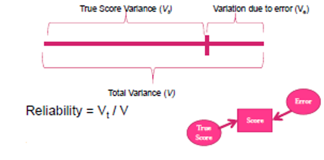

Reliability

There is, though, a better way to take into account measurement error than reliability. In classic measurement theory, reliability is considered as a subset of validity.

When measurements have multiple indicators, each indicator will contain its own specific variance, but it will also contain variance common to the other indicators.

It is this common variance that speaks to the ‘true’ construct of interest.

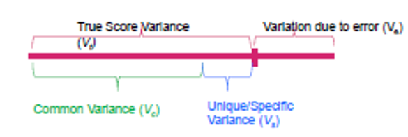

Validity

If we strip away the unique variance of a set of items, we are left with their common variance, which is necessarily measured without error.

So by taking the common variance of a set of items we will be much closer to construct we are interested in (i.e., we have rid it of invalidity and unreliability).

This common variance hence reflects the ‘true’ construct score. And because it is the true construct score, it is measured without error!

How, then, to capture the common variance of items? With latent variables!

We have noted that construct measurement has error variance, unique variance, and common variance.

We can represent these sources of variance in a latent variable as such:

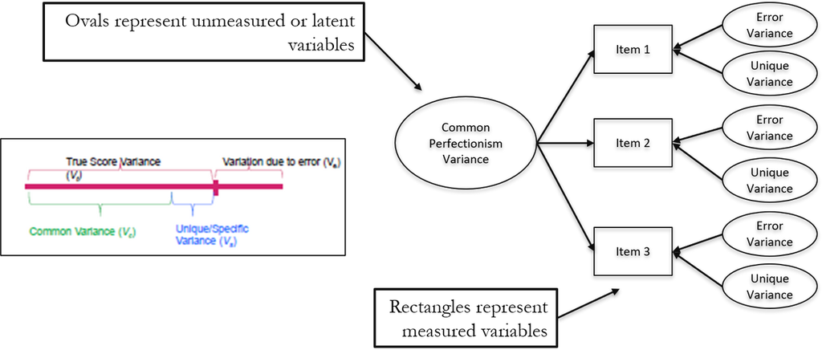

Latent Variable

These are sometimes called factors or latent factors. Typically you will see them referred to as latent variables, though. The common variance of the items is captured in the latent (oval) variable. What is left, the residual of each item, captures the error variance.

Two statistical methods are available to us in the analysis of measurement using latent variables.

1. Exploratory Factor Analysis if the factor structure of the items is unknown
2. Confirmatory Factor Analysis if the factor structure of the items is known

Let’s begin with Exploratory Factor Analysis

# Exploratory Factor Analysis (EFA)

## What is EFA?

In psychology, we often try to measure things that cannot directly be measured. For example, management researchers might be interested in measuring ‘burnout’, which is when someone who has been working very hard on a project for a prolonged period of time suddenly finds themselves devoid of motivation and inspiration.

You cannot measure burnout directly: it has many facets. However, you can measure different aspects of burnout. You could get some idea of motivation, stress levels, and so on.

Having done this, it would be helpful to know whether these differences really do reflect a single variable. Put another way, are these different variables driven by the same underlying variable?

Factor analysis (and Principal Components Analysis) is a technique for identifying groups or clusters of variables for a pool of items.

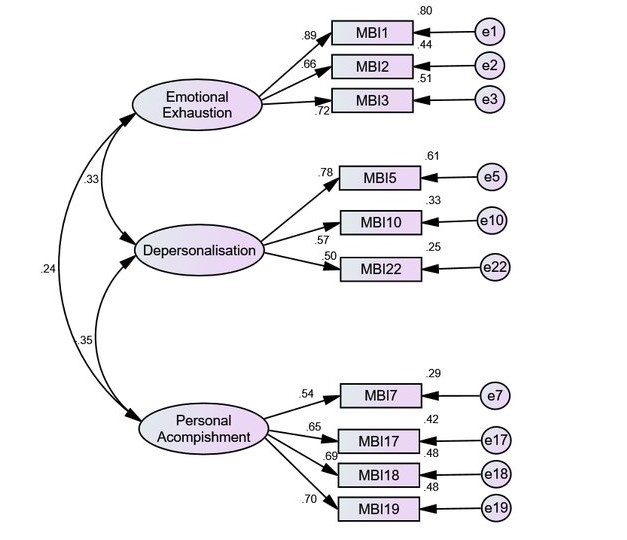

Clusters of Items Refecting the Different Factors of Burnout

EFA is an exploratory technique because it does not assume a factor structure for the items. It starts with the assumption of hidden latent variables which cannot be observed directly but are reflected in the answers the items in our questionnaire.

In this way, EFA finds the most optimal factor structure from the underlying items.

## What is a Factor?

If we take several items on a questionnaire, the correlation between each pair of items can be arranged in what’s known as an R-matrix. An R-matrix is just a correlation matrix: a table of correlation coefficients between variables.

The diagonal elements of an R-matrix are all 1 because each variable will correlate perfectly with itself. The off-diagonal elements are the correlation coefficients between pairs of items.

The existence of clusters of large correlation coefficients between subsets of variables suggests that those variables could be measuring aspects of the same underlying dimension. These underlying dimensions are known as factors (or latent variables, same thing).

By reducing a data set from a items into a smaller set of factors, factor analysis achieves parsimony by explaining the maximum amount of common variance in a correlation matrix using the smallest number of explanatory constructs.

In other words, factors are a small set of clusters of interrelated items that can explain most of the common variance.

## What is a Factor Loading?

If we visualize factors as classification axes, then each variable can be plotted along with each classification axis. For example, two factors (e.g., “Sociability” and “Consideration”) can be plotted as a 2D graph, while six variables (e.g., “Selfish”) can be put at corresponding positions on the graph, as shown below. Such factor plot can be drawn after two factors have been extracted via techniques described in later section that best summarize the items into two clusters.

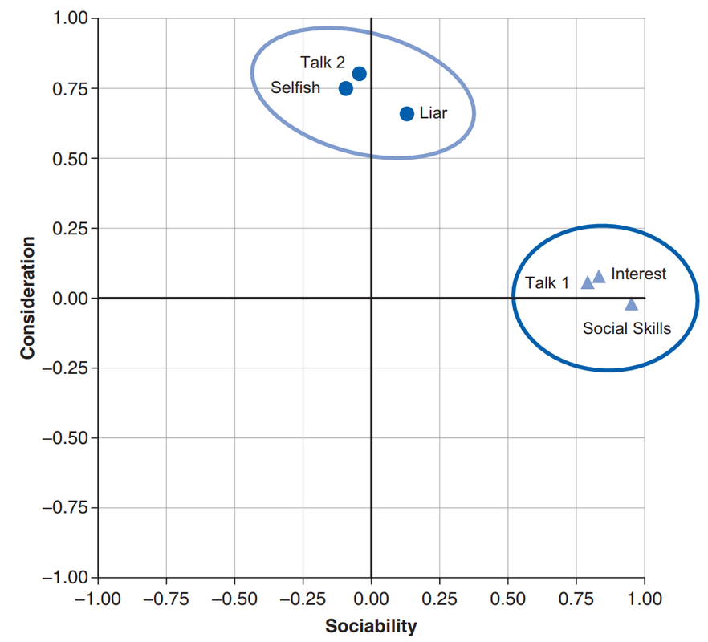

EFA

A factor loading means the coordinate of a item along a classification axis for extracted factors. The factor loading can be thought of as the Pearson correlation between a factor and a variable. You know what that is!

## What is communality?

The total variance for a particular item, as we have seen, will have two components: some of it will be shared with other variables or measures (common variance) and some of it will be specific to that measure (unique variance).

We tend to use the term unique variance to refer to variance that can be reliably attributed to only one item. However, again as we know, there is also variance that is specific to one item but not reliably so. This variance is called error variance and is what is left after common variance and unique variance are subtracted out.

The proportion of common variance present in an item is known as the communality. As such, an item that has no unique or error variance would have a communality of 1, an item that shares none of its variance with any other variable would have a communality of 0.

In factor analysis we are interested in finding common underlying dimensions within the data and so we are primarily interested only in the common variance. Therefore, when we run a factor analysis it is fundamental that we know how much of the variance present in our data is common variance.

## How to Calculate Communality?

There are various methods of estimating communalities, but the most widely used is to use the squared multiple correlation (SMC) of each variable with all others. So, for the popularity data, imagine you ran a multiple regression using one measure (Selfish) as the outcome and the other five measures as predictors: the resulting multiple R2 would be used as an estimate of the communality for the variable Selfish. This second approach is used in factor analysis.

## Factor analysis vs. Principal Components Analysis (PCA)

Strictly speaking, what we are working with in this unit is PCA not factor analysis. Factor analysis derives a mathematical model from which factors are estimated, whereas PCA merely decomposes the original data into a set of optimally weighted latent variables (much like multiple regression!)

Because PCA is a perfectly good procedure and conceptually less complex than factor analysis, we are going to work with it here.

PCA combines common and specific variance into explained variance. The total item variance is used in the positive diagonal of the observed correlation matrix before factor extraction. It finds components that maximize the amount of the total variance that is explained.

PCA aims to identify a new smaller set of latent variables, called principal components, that explain the total variance. PCA assumes that this total variance reflects the sum of explained and error variance. Each principle component is a linear function of the original variables.

For example, lets say we have 12 items for our new questionnaire, each are standardized with a sum of squares of 1. In total, our data set contains 12 items with 12 sum of squares.

If we pool all the items into one factor, we explain half of the variance in the dataset (i.e., explained variance = 6 sum of squares, error variance = 6 sum of squares). If we were to split the items across two factors, we explain a further 4 sum of squares (i.e., explained variance = 10 sum of squares, error variance 2 sum of squares). If we further split the items across three factors we explain all the variance in the data set (i.e., explained variance = 12 sum of squares, error variance 0 sum of squares). The three factors can replace the 12 items without losing any information. This is goal of factor analysis

However, it is rarely this simple. There will always be some error variance unless the number of factors extracted equals the number of items. So the question is: when to stop? When do we have a factor structure that most parsimoniously describes the interrelationships between the items?

There are a variety of approaches to determine the number of factors to extract. These include:

1. The percentage of variance explained, e.g. stop at 75%
2. A priori criterion, i.e., a decision is made to identify a particular number of factors.
3. Kaiser’s (1960) stopping rule. Extract only factors wit an eigenvalue of 1 or more. An eignenvalue is variance explained, the sum of squares for the factor.
4. Inspect a Scree Plot for the critical inflection point (Cattell, 1958).

We are going to use methods 3 and 4 because they are the more universally accepted.

## Factor Rotation

Once factors have been extracted, it is possible to calculate the factor loading.

Generally, you will find that most variables have high loadings on the most important factor and small loadings on all other factors. This characteristic makes interpretation difficult, and so a technique called factor rotation is used to discriminate between factors. If a factor is a classification axis along which variables can be plotted, then factor rotation effectively rotates these factor axes such that variables are loaded maximally on only one factor.

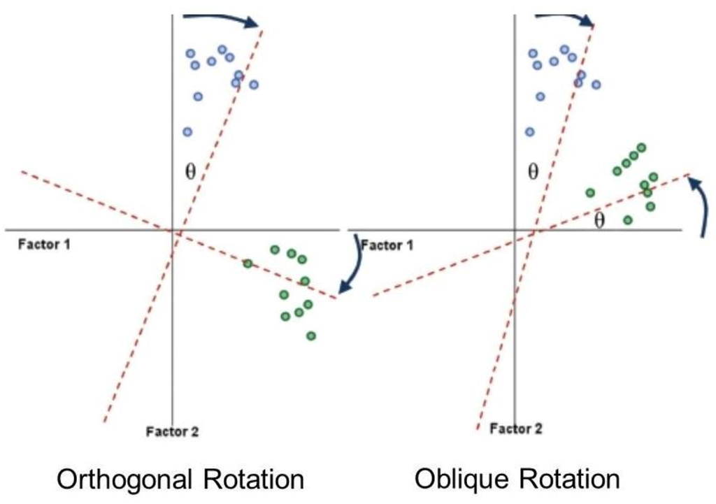

Factor Rotation

There are two types of rotation that can be done. The first is orthogonal rotation while the other is oblique rotation. The difference with oblique rotation is that the factors are allowed to correlate. We will use orthogonal rotation here, sometimes called varimax rotation.

## Example: Anxiety Questionnaire

The main usage of factor analysis is the psychological and behavioral scientists is to develop questionnaires. If we want to measure something, we need to ensure that the questions asked relate to the construct that we intend to measure.

Below is the screen shot of a questionnaire of statistics anxiety (copied from the Andy Field’s book):

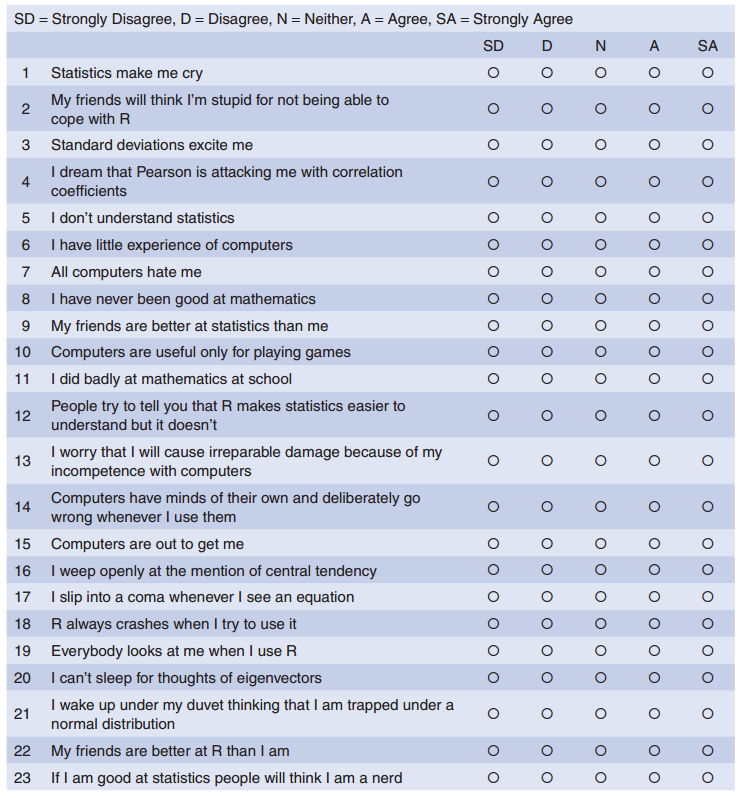

Anxiety Questionnaire

The questionnaire was designed to predict how anxious a given individual would be about learning how to use R. What’s more, they wanted to know whether anxiety about R could be broken down into specific forms of anxiety. In other words, what latent variables contribute to anxiety about R?

With a little help from a few lecturer friends the researcher collected 2571 completed questionnaires (at this point it should become apparent that this example is fictitious). We are going to work with this data today.

Lets load the data into R

```r
library(readr)
anxiety <- read_csv("C:/Users/CURRANT/Dropbox/Work/LSE/PB230/LT3/Workshop/anxiety.csv")
```

```
* `` -> ...1
```

```r
head(anxiety)
```

| ...1 | Q01 | Q02 | Q03 | Q04 | Q05 | Q06 | Q07 | Q08 | Q09 | Q10 | Q11 | Q12 | Q13 | Q14 | Q15 | Q16 | Q17 | Q18 | Q19 | Q20 | Q21 | Q22 | Q23 |
| --- | --- | --- | --- | --- | --- | --- | --- | --- | --- | --- | --- | --- | --- | --- | --- | --- | --- | --- | --- | --- | --- | --- | --- |
| 1 | 4 | 5 | 2 | 4 | 4 | 4 | 3 | 5 | 5 | 4 | 5 | 4 | 4 | 4 | 4 | 3 | 5 | 4 | 3 | 4 | 4 | 4 | 1 |
| 2 | 5 | 5 | 2 | 3 | 4 | 4 | 4 | 4 | 1 | 4 | 4 | 3 | 5 | 3 | 2 | 3 | 4 | 4 | 3 | 2 | 2 | 2 | 4 |
| 3 | 4 | 3 | 4 | 4 | 2 | 5 | 4 | 4 | 4 | 4 | 3 | 3 | 4 | 2 | 4 | 3 | 4 | 3 | 5 | 2 | 3 | 4 | 4 |
| 4 | 3 | 5 | 5 | 2 | 3 | 3 | 2 | 4 | 4 | 2 | 4 | 4 | 4 | 3 | 3 | 3 | 4 | 2 | 4 | 2 | 2 | 2 | 3 |
| 5 | 4 | 5 | 3 | 4 | 4 | 3 | 3 | 4 | 2 | 4 | 4 | 3 | 3 | 4 | 4 | 4 | 4 | 3 | 3 | 2 | 4 | 2 | 2 |
| 6 | 4 | 5 | 3 | 4 | 2 | 2 | 2 | 4 | 2 | 3 | 4 | 2 | 3 | 3 | 1 | 4 | 3 | 1 | 5 | 1 | 3 | 5 | 2 |

You will see that the dataset contains responses to 23 items regarding R anxiety. Great we can get started factor analyzing to see whether we can identify the optimal factor structure from the underlying items.